# Reproducible Research: Peer Assessment 1

Haarkin898

October 13 2020

## Load libraries needed for the analysis (Quest 1)

```r
        library(dplyr)
        library(lubridate)
```

```r
        library(ggplot2)
```

## read in the data set and assign it to an Object

```r
        ACM = read.csv("./activity.csv")
        head(ACM, 3)
```

```
##   steps       date interval
## 1    NA 2012-10-01        0
## 2    NA 2012-10-01        5
## 3    NA 2012-10-01       10
```

```r
        str(ACM)
```

```
## 'data.frame':    17568 obs. of  3 variables:
##  $ steps   : int  NA NA NA NA NA NA NA NA NA NA ...
##  $ date    : Factor w/ 61 levels "2012-10-01","2012-10-02",..: 1 1 1 1 1 1 1 1 1 1 ...
##  $ interval: int  0 5 10 15 20 25 30 35 40 45 ...
```

## refine the date variable, convert to date class and add as variable

```r
        A <- as.Date(ACM$date, format = "%Y-%m-%d")
        class(A)
```

```
## [1] "Date"
```

```r
        ACM$A <- A
        ACM = rename(ACM, Date = A)
        ACM$date = NULL
```

## Group data by Date and analyze

```r
        ACMbyDate = group_by(ACM, Date)
        ACMsum = summarise(ACMbyDate , steps = sum(steps, na.rm = TRUE) )
```

## Plot histogram of above analysis

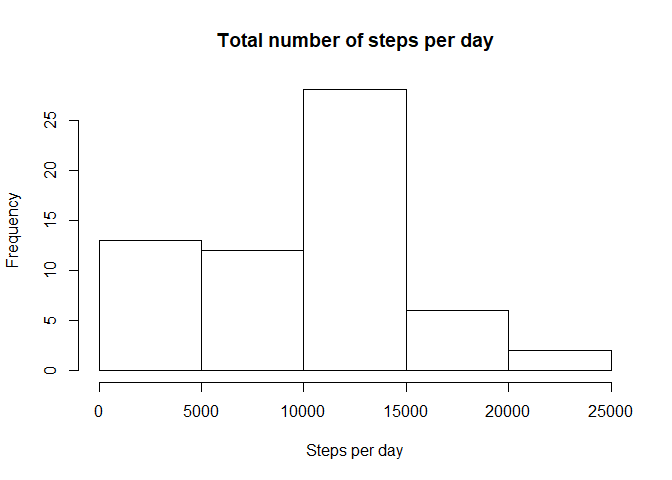

```r
        with(ACMsum, hist(steps, main = "Total number of steps per day",
                          xlab ="Steps per day"))
```

## Determine mean and median steps per day

```r
 ACMsum = rename(ACMsum, TotalSteps = steps)
 Mean = mean(ACMsum$TotalSteps)
 Median = median(ACMsum$TotalSteps)
```

The mean and median of the total number of steps taken per day are 9354.2295082 and 10395 respectively

## Average daily activity time series

```r
        ACMbyInterval = group_by(ACM, interval)
        ACMbyInterval = summarise(ACMbyInterval , steps = mean(steps,
                                                               na.rm = TRUE) )
```

## Plot analysis from above

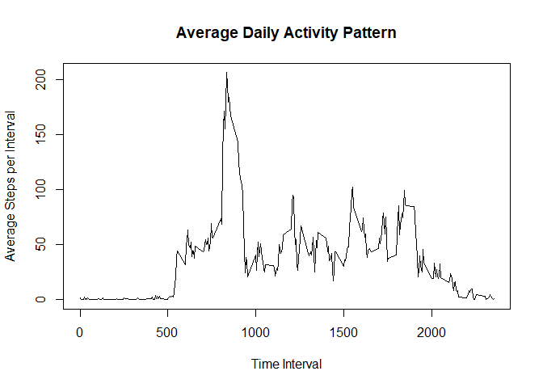

```r
        with(ACMbyInterval, plot(interval, steps, type = "l",
        main = "Average Daily Activity Pattern", xlab = "Time Interval"
                                 , ylab = "Average Steps per Interval"))
```

## interval with the maximum number of steps

```r
        maxInterval = ACMbyInterval[which.max(ACMbyInterval$steps),]$interval
```

The interval with the maximum number of steps is 835

## In-filling missing values with interval mean

filling with daily mean is unlikely to change the output of the analysis as this will only return the same number of NA as the original dataset. The dplyr library was used in this analysis

```r
        sumACM = sum(is.na(ACM))

        impute.mean <- function(x) replace(x, is.na(x), mean(x, na.rm = TRUE))

        ACM3 <- ACM

        ACM3 = ACM3 %>%
                group_by(interval) %>%
                mutate(
                        steps = impute.mean(steps)
                )

        sumACM3 = sum(is.na(ACM3))
```

The sum of NAs in the original data, ACM, and the infilled data, ACM3, are 2304 and 0 respectively.

## Histogram Plot of refined dataset ACM3 with respect to Total number of Steps per day

Group data by Date and analyze

```r
        ACM3byDate = group_by(ACM3, Date)
        ACM3sum = summarise(ACM3byDate , steps = sum(steps, na.rm = TRUE) )
        Mean2 = mean(ACM3sum$steps)
        Median2 = median(ACM3sum$steps)
```

## Plot histogram of above analysis

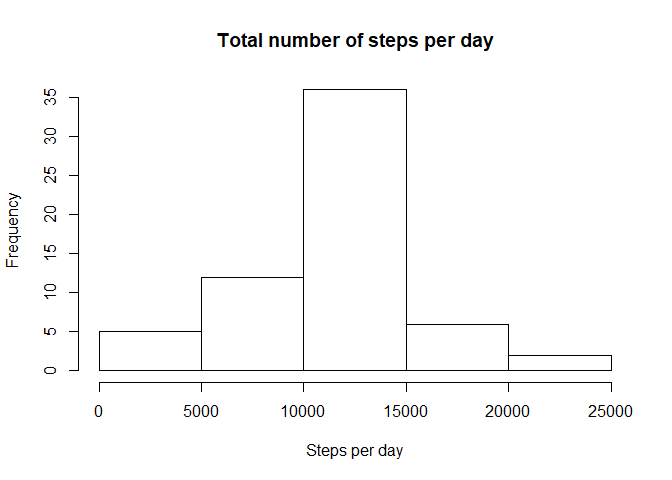

```r
        with(ACM3sum, hist(steps, main = "Total number of steps per day",
                          xlab ="Steps per day"))
```

## Time series analysis based on day type i.e. weekday vs weekends

```r
        Day <- weekdays(ACM3$Date)
        ACM3$Day = Day
        ACM3$Daytype <- ifelse(ACM3$Day %in% c("Saturday", "Sunday"), "weekend",
                               "weekday")
        ACM3$Daytype = factor(ACM3$Daytype)

        ACMbyInt = group_by(ACM3, interval, Daytype)
        ACMbyInt = summarize(ACMbyInt, steps = mean(steps))
```

##Plot

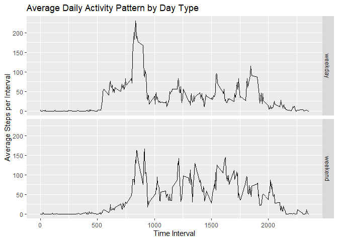

```r
        g <- ggplot(ACMbyInt, aes(x=interval, y=steps)) +
                geom_line() + facet_grid(Daytype~.) +
                labs (x = "Time Interval", y = "Average Steps per Interval") +
                labs (title = "Average Daily Activity Pattern by Day Type")
        g
```